# CFA is (kind of) just a mixed effects model

Variances: Estimate Std.Err z-value P(>|z|) Std.lv Std.all .X1 0.383 0.017 21.938 0.000 0.383 0.538 .X2 0.368 0.017 21.693 0.000 0.368 0.424 .X3 0.336 0.015 21.875 0.000 0.336 0.503 .X4 0.349 0.016 21.526 0.000 0.349 0.371 .X5 0.199 0.009 20.899 0.000 0.199 0.252 .X6 0.296 0.013 22.089 0.000 0.296 0.644 .X7 0.348 0.016 21.857 0.000 0.348 0.494 .X8 0.270 0.013 21.343 0.000 0.270 0.326 .X9 0.258 0.012 21.607 0.000 0.258 0.395 .X10 0.242 0.011 21.690 0.000 0.242 0.423 .X11 0.222 0.011 21.085 0.000 0.222 0.279 .X12 0.292 0.013 21.767 0.000 0.292 0.453 .X13 0.282 0.013 21.554 0.000 0.282 0.379 .X14 0.272 0.013 21.606 0.000 0.272 0.395 .X15 0.229 0.010 21.928 0.000 0.229 0.532 .X16 0.230 0.011 21.235 0.000 0.230 0.304 .X17 0.250 0.011 21.882 0.000 0.250 0.507 .X18 0.289 0.013 22.081 0.000 0.289 0.638 .X19 0.257 0.012 21.743 0.000 0.257 0.443 .X20 0.375 0.017 21.508 0.000 0.375 0.366 .X21 0.204 0.010 20.897 0.000 0.204 0.252 .X22 0.293 0.014 21.580 0.000 0.293 0.387 .X23 0.345 0.016 21.740 0.000 0.345 0.442 .X24 0.237 0.011 20.946 0.000 0.237 0.258 .X25 0.304 0.014 21.678 0.000 0.304 0.419 .X26 0.244 0.011 21.456 0.000 0.244 0.352 .X27 0.218 0.010 21.422 0.000 0.218 0.344 .X28 0.360 0.017 21.820 0.000 0.360 0.476 .X29 0.367 0.017 22.002 0.000 0.367 0.579 .X30 0.269 0.012 21.995 0.000 0.269 0.574 Factor 1.000 1.000 1.000

[output not shown]

```r
NA
```

[output not shown]

```r
NA
```

[output not shown]

```r
NA
```

[output not shown]

Family: gaussian Links: mu = identity; sigma = identity Formula: item_score ~ intercept + loading * lvscore lvscore ~ 0 + (1 | participant) loading ~ 0 + (1 | item) intercept ~ 0 + (1 | item) Data: dat_long (Number of observations: 30000) Draws: 4 chains, each with iter = 2000; warmup = 1000; thin = 1; total post-warmup draws = 4000

Multilevel Hyperparameters: ~participant (Number of levels: 1000) Estimate Est.Error l-95% CI u-95% CI Rhat Bulk_ESS Tail_ESS sd(lvscore_Intercept) 1.00 0.00 1.00 1.00 NA NA NA

~item (Number of levels: 30) Estimate Est.Error l-95% CI u-95% CI Rhat Bulk_ESS Tail_ESS sd(loading_Intercept) 0.66 0.08 0.51 0.85 1.03 187 426 sd(intercept_Intercept) 3.31 0.39 2.65 4.15 1.01 184 328

Further Distributional Parameters: Estimate Est.Error l-95% CI u-95% CI Rhat Bulk_ESS Tail_ESS sigma 0.54 0.00 0.53 0.54 1.00 8187 2997

Draws were sampled using sampling(NUTS). For each parameter, Bulk_ESS and Tail_ESS are effective sample size measures, and Rhat is the potential scale reduction factor on split chains (at convergence, Rhat = 1).

[output not shown]

```r
plot(x = true_item_intercepts,
     y = parameter_summary$Intercept,
     xlab = "",
     ylab = "")

plot(x = latent_factor,
     y = ranef(fit_mem)$participant[,"Estimate","lvscore_Intercept"],
     xlab = "True LV score",
     ylab = "Bayesian non-linear regression\n(brms)")
```

```r
plot(x = true_factor_loadings,
     y = ranef(fit_mem)$item[,"Estimate","loading_Intercept"],
     xlab = "True loading",
     ylab = "")
plot(x = true_item_intercepts,
     y = ranef(fit_mem)$item[,"Estimate","intercept_Intercept"],
     xlab = "True intercept",
     ylab = "")
```

```r
p <- recordPlot()

png("plot.png", width = 600, height = 400)
replayPlot(p)
```

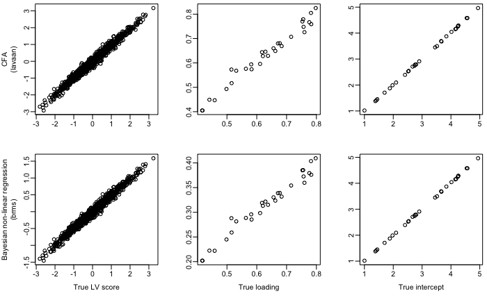

```r
dev.off()
```

[^1]: Although `brms` will (or, depending on when you read this, does) have functionality specifically for estimating factor models, this notebook deliberately specifies the mixed effects model in a way that’s probably most familiar to people coming from a mixed model / HLM background.